# Project

Parth Pandya

# PROJECT DA 5030

**Bank marketing Dataset**

- Acquiring the dataset

Using the same dataset twice for comparison.

```r
banking_test<-read.csv("bank_test.csv",sep = ";")
bank_test<-read.csv("bank_test.csv",sep = ";",stringsAsFactors = F)
bank_test$y<-as.factor(bank_test$y)
summary(banking_test)
```

```
      age                 job           marital
 Min.   :18.00   admin.     :1012   divorced: 446
 1st Qu.:32.00   blue-collar: 884   married :2509
 Median :38.00   technician : 691   single  :1153
 Mean   :40.11   services   : 393   unknown :  11
 3rd Qu.:47.00   management : 324
 Max.   :88.00   retired    : 166
                 (Other)    : 649
               education       default        housing          loan
 university.degree  :1264   no     :3315   no     :1839   no     :3349
 high.school        : 921   unknown: 803   unknown: 105   unknown: 105
 basic.9y           : 574   yes    :   1   yes    :2175   yes    : 665
 professional.course: 535
 basic.4y           : 429
 basic.6y           : 228
 (Other)            : 168
      contact         month      day_of_week    duration
 cellular :2652   may    :1378   fri:768     Min.   :   0.0
 telephone:1467   jul    : 711   mon:855     1st Qu.: 103.0
                  aug    : 636   thu:860     Median : 181.0
                  jun    : 530   tue:841     Mean   : 256.8
                  nov    : 446   wed:795     3rd Qu.: 317.0
                  apr    : 215               Max.   :3643.0
                  (Other): 203
    campaign          pdays          previous             poutcome
 Min.   : 1.000   Min.   :  0.0   Min.   :0.0000   failure    : 454
 1st Qu.: 1.000   1st Qu.:999.0   1st Qu.:0.0000   nonexistent:3523
 Median : 2.000   Median :999.0   Median :0.0000   success    : 142
 Mean   : 2.537   Mean   :960.4   Mean   :0.1903
 3rd Qu.: 3.000   3rd Qu.:999.0   3rd Qu.:0.0000
 Max.   :35.000   Max.   :999.0   Max.   :6.0000

  emp.var.rate      cons.price.idx  cons.conf.idx     euribor3m
 Min.   :-3.40000   Min.   :92.20   Min.   :-50.8   Min.   :0.635
 1st Qu.:-1.80000   1st Qu.:93.08   1st Qu.:-42.7   1st Qu.:1.334
 Median : 1.10000   Median :93.75   Median :-41.8   Median :4.857
 Mean   : 0.08497   Mean   :93.58   Mean   :-40.5   Mean   :3.621
 3rd Qu.: 1.40000   3rd Qu.:93.99   3rd Qu.:-36.4   3rd Qu.:4.961
 Max.   : 1.40000   Max.   :94.77   Max.   :-26.9   Max.   :5.045

  nr.employed     y
 Min.   :4964   no :3668
 1st Qu.:5099   yes: 451
 Median :5191
 Mean   :5166
 3rd Qu.:5228
 Max.   :5228
```

```r
str(banking_test)
```

```
'data.frame':   4119 obs. of  21 variables:
 $ age           : int  30 39 25 38 47 32 32 41 31 35 ...
 $ job           : Factor w/ 12 levels "admin.","blue-collar",..: 2 8 8 8 1 8 1 3 8 2 ...
 $ marital       : Factor w/ 4 levels "divorced","married",..: 2 3 2 2 2 3 3 2 1 2 ...
 $ education     : Factor w/ 8 levels "basic.4y","basic.6y",..: 3 4 4 3 7 7 7 7 6 3 ...
 $ default       : Factor w/ 3 levels "no","unknown",..: 1 1 1 1 1 1 1 2 1 2 ...
 $ housing       : Factor w/ 3 levels "no","unknown",..: 3 1 3 2 3 1 3 3 1 1 ...
 $ loan          : Factor w/ 3 levels "no","unknown",..: 1 1 1 2 1 1 1 1 1 1 ...
 $ contact       : Factor w/ 2 levels "cellular","telephone": 1 2 2 2 1 1 1 1 1 2 ...
 $ month         : Factor w/ 10 levels "apr","aug","dec",..: 7 7 5 5 8 10 10 8 8 7 ...
 $ day_of_week   : Factor w/ 5 levels "fri","mon","thu",..: 1 1 5 1 2 3 2 2 4 3 ...
 $ duration      : int  487 346 227 17 58 128 290 44 68 170 ...
 $ campaign      : int  2 4 1 3 1 3 4 2 1 1 ...
 $ pdays         : int  999 999 999 999 999 999 999 999 999 999 ...
 $ previous      : int  0 0 0 0 0 2 0 0 1 0 ...
 $ poutcome      : Factor w/ 3 levels "failure","nonexistent",..: 2 2 2 2 2 1 2 2 1 2 ...
 $ emp.var.rate  : num  -1.8 1.1 1.4 1.4 -0.1 -1.1 -1.1 -0.1 -0.1 1.1 ...
 $ cons.price.idx: num  92.9 94 94.5 94.5 93.2 ...
 $ cons.conf.idx : num  -46.2 -36.4 -41.8 -41.8 -42 -37.5 -37.5 -42 -42 -36.4 ...
 $ euribor3m     : num  1.31 4.86 4.96 4.96 4.19 ...
 $ nr.employed   : num  5099 5191 5228 5228 5196 ...
 $ y             : Factor w/ 2 levels "no","yes": 1 1 1 1 1 1 1 1 1 1 ...
```

From summary we can see that marital,default,housing,loan, poutcome have “unknown”" values

Dataset comprises of 21 features: 20 independent variables: (10 categorical features)- job,marital,education,default,housing,loan,contact,month, day_of_week, poutcome

10 numeric features

- Analysing the features

```r
#duration
duration<- which(bank_test$duration==0)
bank_test[duration,]
```

|  | age | job | marital | education | default | housing | loan | contact | month | day_of_week | duration | campaign | pdays | previous | poutcome | emp.var.rate | cons.price.idx | cons.conf.idx | euribor3m | nr.employed | y |
| --- | --- | --- | --- | --- | --- | --- | --- | --- | --- | --- | --- | --- | --- | --- | --- | --- | --- | --- | --- | --- | --- |
| 1951 | 39 | admin. | married | high.school | no | yes | no | telephone | may | tue | 0 | 4 | 999 | 0 | nonexistent | 1.1 | 93.994 | -36.4 | 4.857 | 5191 | no |

```r
duration1<- which(bank_test$duration<100)
bank_test[duration1,]
```

|  | age | job | marital | education | default | housing | loan | contact | month | day_of_week | duration | campaign | pdays | previous | poutcome | emp.var.rate | cons.price.idx | cons.conf.idx | euribor3m | nr.employed | y |
| --- | --- | --- | --- | --- | --- | --- | --- | --- | --- | --- | --- | --- | --- | --- | --- | --- | --- | --- | --- | --- | --- |
| 4 | 38 | services | married | basic.9y | no | unknown | unknown | telephone | jun | fri | 17 | 3 | 999 | 0 | nonexistent | 1.4 | 94.465 | -41.8 | 4.959 | 5228.1 | no |
| 5 | 47 | admin. | married | university.degree | no | yes | no | cellular | nov | mon | 58 | 1 | 999 | 0 | nonexistent | -0.1 | 93.200 | -42.0 | 4.191 | 5195.8 | no |
| 8 | 41 | entrepreneur | married | university.degree | unknown | yes | no | cellular | nov | mon | 44 | 2 | 999 | 0 | nonexistent | -0.1 | 93.200 | -42.0 | 4.191 | 5195.8 | no |
| 9 | 31 | services | divorced | professional.course | no | no | no | cellular | nov | tue | 68 | 1 | 999 | 1 | failure | -0.1 | 93.200 | -42.0 | 4.153 | 5195.8 | no |
| 13 | 36 | admin. | married | high.school | no | no | no | telephone | may | wed | 97 | 2 | 999 | 0 | nonexistent | 1.1 | 93.994 | -36.4 | 4.859 | 5191.0 | no |
| 18 | 46 | admin. | divorced | university.degree | no | yes | no | telephone | jul | mon | 59 | 4 | 999 | 0 | nonexistent | 1.4 | 93.918 | -42.7 | 4.962 | 5228.1 | no |
| 19 | 45 | entrepreneur | married | university.degree | unknown | yes | yes | cellular | aug | mon | 38 | 2 | 999 | 0 | nonexistent | 1.4 | 93.444 | -36.1 | 4.965 | 5228.1 | no |
| 28 | 28 | blue-collar | married | basic.6y | unknown | no | no | cellular | may | mon | 68 | 2 | 999 | 1 | failure | -1.8 | 92.893 | -46.2 | 1.299 | 5099.1 | no |
| 35 | 48 | technician | married | university.degree | no | no | no | cellular | aug | thu | 42 | 7 | 999 | 0 | nonexistent | 1.4 | 93.444 | -36.1 | 4.962 | 5228.1 | no |
| 37 | 36 | blue-collar | married | basic.6y | no | yes | no | telephone | may | wed | 57 | 1 | 999 | 0 | nonexistent | 1.1 | 93.994 | -36.4 | 4.859 | 5191.0 | no |

[output cut: 962 more lines]

There is 1 value which is equal to zero which indicate that the customer did not subscribe for the term.

If we test for values less than 100 second there are about 1000 customers who did not subscribe for the term.

Hence we get biased decision for less number of duration. We will build a model with and without this feature and compare the performance.

Age and euribor has some outlier values but they are not any random values or miscalcualted values hence we will not replace those values.

- Outlier detection

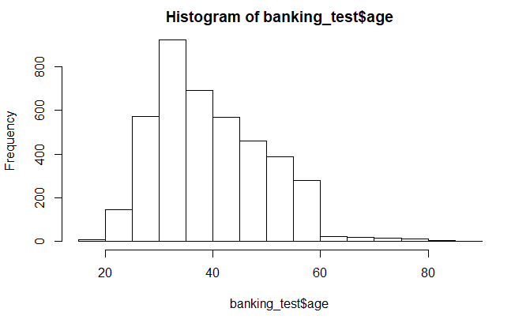

```r
library(DMwR)
hist(banking_test$age)
```

```r
z_age<-abs(scale(banking_test$age,center = TRUE,scale=TRUE))
out_age<-which(z_age>3)
str(out_age)
```

```
 int [1:32] 43 129 151 229 339 451 538 590 697 751 ...
```

```r
str(out_age)
```

```
 int [1:32] 43 129 151 229 339 451 538 590 697 751 ...
```

```r
age_out<-banking_test[out_age,]
nrow(age_out)
```

```
[1] 32
```

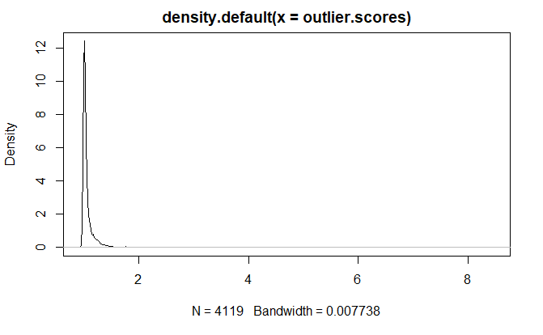

```r
n<-nrow(banking_test)
bank_out<-banking_test[,c("age","euribor3m","duration","emp.var.rate","nr.employed","pdays")]
outlier.scores<-lofactor(bank_out,k=60)
plot(density(outlier.scores))
```

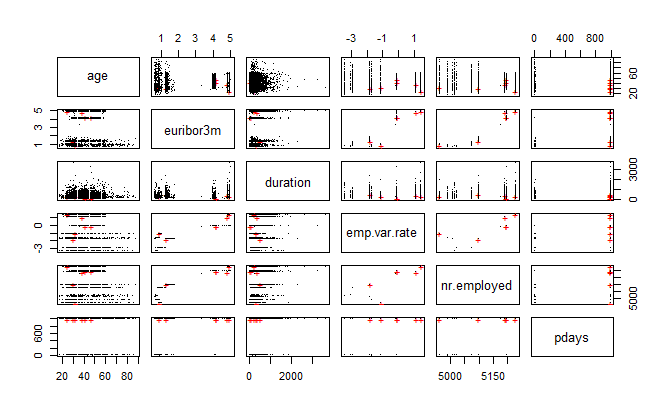

```r
#visualize outlier
pch <- rep(".", n)
pch[outlier.scores] <- "+"
col <- rep("black", n)
col[outlier.scores] <- "red"
pairs(bank_out, pch=pch, col=col)
```

```r
#pdays feature analysis
pastdays<-which(banking_test$pdays==999)
str(pastdays)
```

```
 int [1:3959] 1 2 3 4 5 6 7 8 9 10 ...
```

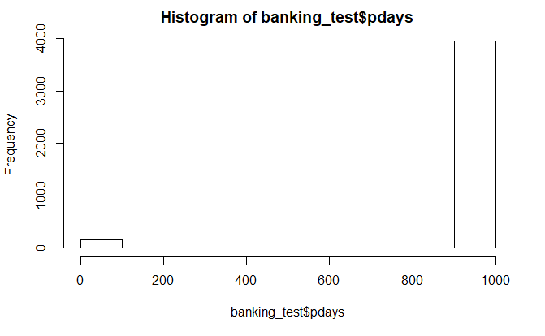

```r
hist(banking_test$pdays)
```

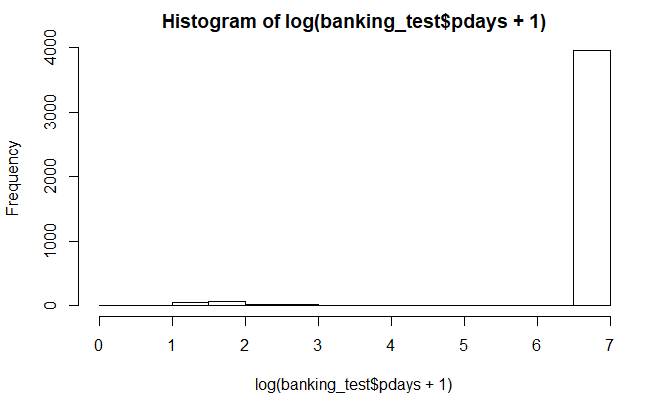

```r
#heavily skewed towards left
#applying some transformations
hist(log(banking_test$pdays+1))
```

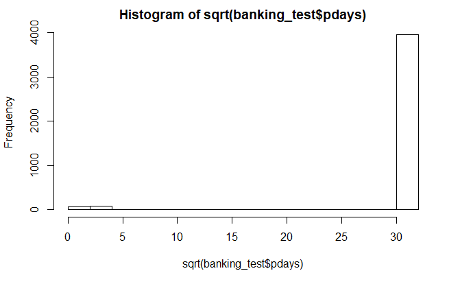

```r
hist(sqrt(banking_test$pdays))
```

- The features have some outliers which skew the data minimally but these are not random values and it is possible to have such values in real world scenario hence we will keep the outlier values as it is and it won’t affect out model that much.
- pdays has majority of values equal to 999 which means there was no previous contact hence it is better to eliminate this feature from our analysis as again imputing will consist biased values.
- For example age has outlier values above 73 years of age in the dataset. It is possible to have the age of a client to be 73 or above.

*Replacing “unknown” “nonexitent” cases and imputing them.

```r
banking_testimpute<-read.csv("bank_test.csv",sep=";",na.strings = c("unknown","nonexistent"))

#we will use the test data to reduce time complexity of model training and imputing

#numeric features
bankingtest_num<-as.data.frame(banking_testimpute[c('age','day_of_week','duration','campaign','pdays','previous','emp.var.rate','cons.price.idx','cons.conf.idx','euribor3m','nr.employed')])

bankingtest_cat<-as.data.frame(banking_testimpute[c(2,3,4,5,6,7,8,9,10,15,21)])




#imputation using mice
library(mice)
md.pattern(banking_testimpute)
banking_testimpute$y<-as.factor(ifelse(banking_testimpute$y=="no",0,1))
#install.packages("VIM")
library(VIM)
mice_plot <- aggr(banking_testimpute, col=c('navyblue','yellow'),
                    numbers=TRUE, sortVars=TRUE,
                    labels=names(banking_testimpute), cex.axis=.7,
                    gap=3, ylab=c("Missing data","Pattern"))
imputed_Data <- mice(banking_testimpute, m=5, maxit = 5, method = 'pmm', seed = 500)
model1<-complete(imputed_Data,2)
```

We have imputed the model using mice package now we will compare the performance of the model with imputed data and one without imputation

```r
Kappa(table(predict_m,model1$y))
```

```
            value     ASE     z   Pr(>|z|)
Unweighted 0.6086 0.02191 27.78 8.046e-170
Weighted   0.6086 0.02191 27.78 8.046e-170
```

```r
Kappa(table(predict_m1,banking_test$y))
```

```
            value     ASE     z   Pr(>|z|)
Unweighted 0.5651 0.02301 24.56 3.216e-133
Weighted   0.5651 0.02301 24.56 3.216e-133
```

- Eliminating pdays feature

```r
banking_test<-banking_test[-13]
banking_test<-banking_test[-3927,]
#removing illiterate value from education feature as there is only one value

bank_test<-bank_test[-13]
bank_test<-bank_test[-3927,]

#segmenting features on their type to apply transformations for different models
bank_num<-as.data.frame(banking_test[c('age','campaign','previous','emp.var.rate','cons.price.idx','cons.conf.idx','euribor3m','nr.employed')])

bank_num1<-as.data.frame(bank_test[c('age','campaign','previous','emp.var.rate','cons.price.idx','cons.conf.idx','euribor3m','nr.employed')])

bank_cat<-as.data.frame(banking_test[c(2,3,4,5,6,7,8,9,10,13)])

bank_cat1<-as.data.frame(bank_test[c(2,3,4,5,6,7,8,9,10,13)])
y<-as.factor(banking_test$y) #target variable
y2<-as.factor(banking_test$y)
```

Normalising the numeric feature

- Data correlation/collinearity

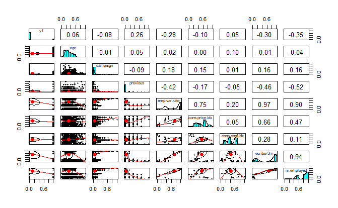

**PCA**

This dataset consists of categorical variables hence I have performed PCA on only numeric features of the dataset.

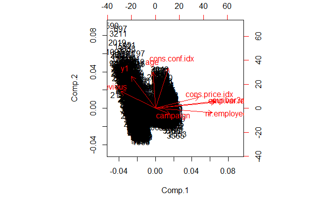

**Creating new feature column** We will be creating two classes for age i.e. adult and senior citizen

```r
table(banking_test$age)
age_new<-ifelse(banking_test$age<50,"adult",banking_test$age)
age_new1<-ifelse(banking_test$age>50,"senior citizen",age_new)
age_new1
```

- Data partition

```r
#dataset without normalization
set.seed(1003)
train <- createDataPartition(banking_test$y, p=0.75, list = FALSE)
banking_trainx<-banking_test[train,]
banking_validx<-banking_test[-train,]
yx<-ifelse(banking_validx$y=="yes",1,0)

#normalized values
set.seed(1002)
train1<-createDataPartition(bank_nd$y2,p=0.75,list=F)
banking_train1<-bank_nd[train1,]
banking_valid1<-bank_nd[-train1,]


prop.table(table(banking_train1$y))
prop.table(table(banking_valid1$y))


#confirming the split of our target variable is similar to training and validation set

#strings without factors split
set.seed(1009)
trainx<-createDataPartition(bank_test$y,p=0.75,list=F)
banking_train<-bank_test[trainx,]
banking_valid<-bank_test[-trainx,]
```

**Logistic regression model**

```r
auc_glm
```

```
[1] 0.7402721
```

Accuracy=92% Kappa statistic=0.5422 Auc=0.74

**Neural network model**

```r
nn_model<-train(y~.,data=banking_trainx,method="nnet",trControl=trainControl(method='cv',number=10)) #k-fold cross validation model

nn_model1<-train(y~.,data=banking_trainx,method="nnet",trControl=trainControl(method='LGOCV')) #holdout sampling

nn_predict<-predict(nn_model,banking_validx)
table(nn_predict,banking_validx$y)
confusionMatrix(nn_predict,banking_validx$y)

nn_predict1<-predict(nn_model1,banking_validx)
table(nn_predict1,banking_valid1$y)
confusionMatrix(nn_predict1,banking_validx$y)

nn_predictx<-ifelse(nn_predict=="yes",1,0)
nn_predictx1<-ifelse(nn_predict1=="yes",1,0)

library(ROCR)
library(Metrics)
prediction_nn<-prediction(nn_predictx,yx)
perf <- performance(prediction_nn,measure = "tpr",x.measure = "fpr")
plot(perf)
auc(yx,nn_predictx)


prediction_nn1<-prediction(nn_predictx1,yx)
perf1 <- performance(prediction_nn1,measure = "tpr",x.measure = "fpr")
plot(perf1)
auc(yx,nn_predictx1)
```

k-fold model Accuracy=92% Kappa statistic=0.56 auc=0.766

Hold out model Accuracy=91.83% Kappa stistic=0.5355 auc=0.7425

**SVM model**

```r
confusionMatrix(svm_predict,banking_validx$y)
```

```
Confusion Matrix and Statistics

          Reference
Prediction  no yes
       no  899  81
       yes  17  31

               Accuracy : 0.9047
                 95% CI : (0.8851, 0.9219)
    No Information Rate : 0.8911
    P-Value [Acc > NIR] : 0.08642

                  Kappa : 0.3447
 Mcnemar's Test P-Value : 1.966e-10

            Sensitivity : 0.9814
            Specificity : 0.2768
         Pos Pred Value : 0.9173
         Neg Pred Value : 0.6458
             Prevalence : 0.8911
         Detection Rate : 0.8745
   Detection Prevalence : 0.9533
      Balanced Accuracy : 0.6291

       'Positive' Class : no
```

Accuracy=90.47 Kappa= 0.3447

**Rule Learner Model**

```r
print(auc_Jrip)
```

```
[1] 0.8019729
```

Accuracy=91.25% Kappa=0.5725 auc=0.802

**KNN model**

```r
m_knn<-train(y~.,data=banking_trainx,method="knn",metric="Kappa",trControl=trainControl(method = "cv",number=10),tuneGrid=expand.grid(.k=c(50,55,60)))

m_knn1<-train(y2~.,data=banking_train1,method="knn",metric="Kappa",trControl=trainControl(method = "cv",number=10),tuneGrid=expand.grid(.k=c(50,55,60)))

predict_knn<-predict(m_knn,banking_validx)
table(predict_knn,banking_validx$y)
confusionMatrix(predict_knn,banking_validx$y)




predict_knn1<-ifelse(predict_knn=="yes",1,0)

auc_knn<-auc(yx,predict_knn1)
```

Accuracy=90.76 Kappa=0.4276 auc=0.677

**Regression Tree model**

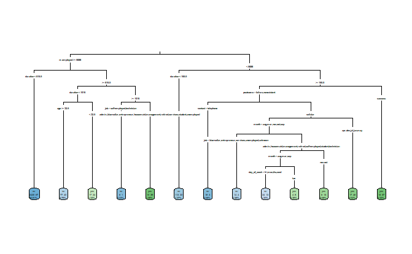

**Random forest**

```r
ctrl_rf <- trainControl(method = "repeatedcv",
number = 10, repeats = 10)

grid_rf <- expand.grid(.mtry = c(2, 4, 8, 16))

set.seed(300)
m_rf <- train(y ~ ., data = banking_trainx, method = "rf",
metric = "Kappa", trControl = ctrl_rf,
tuneGrid = grid_rf)




predict_rf<-predict(m_rf,banking_validx)
table(predict_rf,banking_validx$y)
confusionMatrix(predict_rf,banking_validx$y)

predict_rfn<-ifelse(predict_rf=="yes",1,0)
auc_rf<-auc(yx,predict_rfn)
auc_rf
```

auc=0.718 Kappa=0.509 Accuracy=0.909

**Boosting Decision trees**

```r
install.packages("adabag")
library(adabag)

bankin_boost<-boosting(y~.,data=banking_trainx)

predict_boost<-predict(bankin_boost,banking_validx)

predict_boostn<-ifelse(predict_boost$class=="yes",1,0)

confusionMatrix(predict_boostn,yx)

auc_boost<-auc(predict_boostn,yx)
```

** Ensemble models (knn,svm)**

```r
confusionMatrix(predict_stack,banking_validx$y)
```

```
Confusion Matrix and Statistics

          Reference
Prediction  no yes
       no  882  70
       yes  34  42

               Accuracy : 0.8988
                 95% CI : (0.8788, 0.9166)
    No Information Rate : 0.8911
    P-Value [Acc > NIR] : 0.2281122

                  Kappa : 0.3934
 Mcnemar's Test P-Value : 0.0005991

            Sensitivity : 0.9629
            Specificity : 0.3750
         Pos Pred Value : 0.9265
         Neg Pred Value : 0.5526
             Prevalence : 0.8911
         Detection Rate : 0.8580
   Detection Prevalence : 0.9261
      Balanced Accuracy : 0.6689

       'Positive' Class : no
```

Kappa=0.3934 Accuracy=0.8988